# Caffeine Intake and Decision Fatigue

2026-03-18

## Introduction

This project analyzes the Human Decision Fatigue Behavioral Dataset, published on Kaggle by Sonal Shinde (sonalshinde123). The supplied CSV contains 25,000 simulated records and 13 variables describing decision-making activity, sleep, caffeine intake, stress, and fatigue.

The dataset is synthetic: its records represent simulated decision-making states rather than observations collected from human participants. The fatigue score is constructed from other variables through the data-generation process. Consequently, the relationships examined here may reflect those generation rules and do not establish how caffeine affects fatigue in real people.

The analysis demonstrates exploratory visualization, correlation analysis, and multiple linear regression.

Source: Human Decision Fatigue Behavioral Dataset (https://www.kaggle.com/datasets/sonalshinde123/human-decision-fatigue-behavioral-dataset)

Dataset license: CC0 Public Domain.

## Data Checks

```r
tibble(
  records = nrow(decisions),
  variables = ncol(decisions),
  missing_values = sum(is.na(decisions)),
  duplicate_rows = sum(duplicated(decisions))
)
```

```
## # A tibble: 1 × 4
##   records variables missing_values duplicate_rows
##     <int>     <int>          <int>          <int>
## 1   25000        13              0              1
```

Keeping 1 duplicate row because I cannot prove that it is an erroneous record.

## Exploratory Analysis

Let’s see the distribution of fatigue level to begin

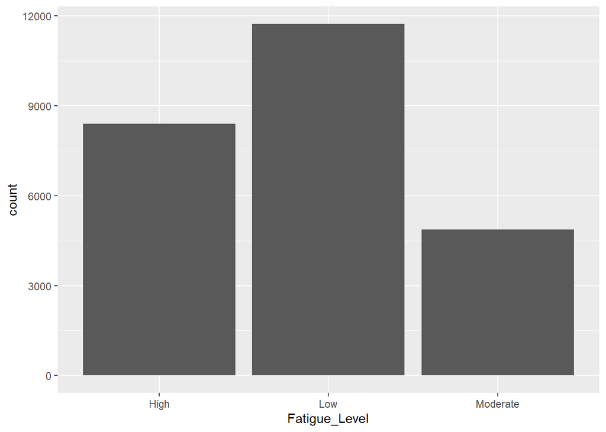

```r
ggplot(decisions) +
  geom_bar(aes(x = Fatigue_Level))
```

```r
decisions |>
  group_by(Fatigue_Level) |>
  summarise(Mean_Decision_Time = mean(Avg_Decision_Time_sec)) |>
  arrange(Mean_Decision_Time)
```

```
## # A tibble: 3 × 2
##   Fatigue_Level Mean_Decision_Time
##   <chr>                      <dbl>
## 1 Low                         2.46
## 2 Moderate                    3.02
## 3 High                        3.51
```

```r
decisions <- decisions |>
  mutate(speed_bins = ntile(Avg_Decision_Time_sec, 3), speed_bins = case_when(speed_bins == 1 ~ "Fast",
      speed_bins == 2 ~ "Medium",
      speed_bins == 3 ~ "Slow"))
# Divide decision times into three approximately equal-sized groups.

decisions |>
  group_by(speed_bins) |>
  summarise(Coffee_Cups_Avg = mean(Caffeine_Intake_Cups))
```

```
## # A tibble: 3 × 2
##   speed_bins Coffee_Cups_Avg
##   <chr>                <dbl>
## 1 Fast                  1.60
## 2 Medium                1.88
## 3 Slow                  2.20
```

```r
# Keep records with identical caffeine intake in the same group.
decisions <- decisions |>
  mutate(
    caffeine_bins = case_when(
      Caffeine_Intake_Cups <= 1 ~ "0-1 cups",
      Caffeine_Intake_Cups == 2 ~ "2 cups",
      Caffeine_Intake_Cups >= 3 ~ "3+ cups"),
    caffeine_bins = factor(
      caffeine_bins,
      levels = c("0-1 cups", "2 cups", "3+ cups")
    )
  )

decisions |>
  group_by(caffeine_bins) |>
  summarise(
    records = n(),
    mean_fatigue = mean(Decision_Fatigue_Score),
    sd_fatigue = sd(Decision_Fatigue_Score),
    .groups = "drop"
  )
```

```
## # A tibble: 3 × 4
##   caffeine_bins records mean_fatigue sd_fatigue
##   <fct>           <int>        <dbl>      <dbl>
## 1 0-1 cups        11144         31.1       34.8
## 2 2 cups           6382         42.0       36.3
## 3 3+ cups          7474         53.5       35.6
```

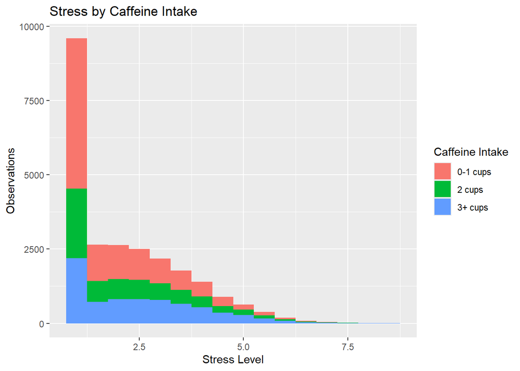

```r
decisions |>
  ggplot() +
  geom_histogram(aes(Stress_Level_1_10, fill = caffeine_bins), binwidth = 0.5) +
  labs(title = "Stress by Caffeine Intake", x = "Stress Level", y = "Observations", fill = "Caffeine Intake")
```

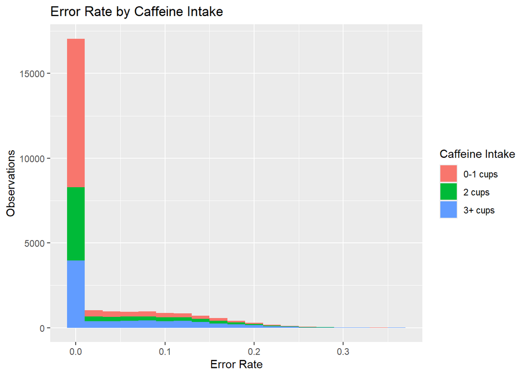

```r
decisions |>
  ggplot() +
  geom_histogram(aes(Error_Rate, fill = caffeine_bins), binwidth = 0.02) +
  labs(title = "Error Rate by Caffeine Intake", x = "Error Rate", y = "Observations", fill = "Caffeine Intake")
```

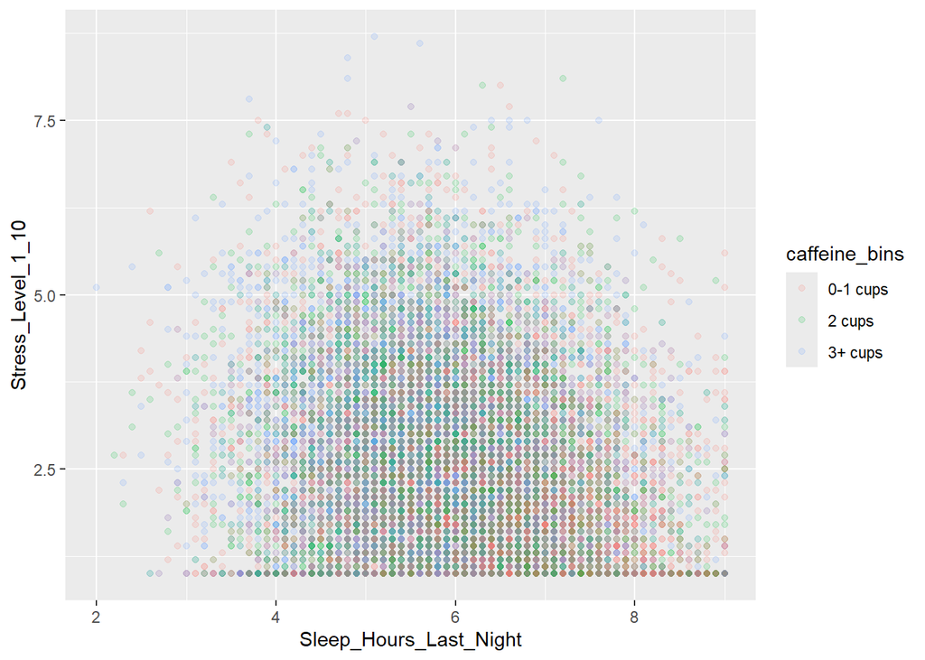

```r
ggplot(decisions) +
  geom_point(aes(Sleep_Hours_Last_Night, Stress_Level_1_10, color = caffeine_bins), alpha = 0.15)
```

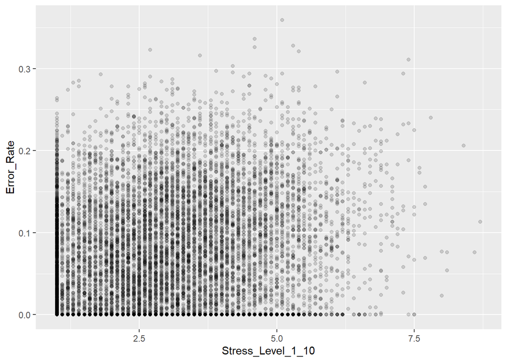

```r
ggplot(decisions) +
  geom_point(aes(Stress_Level_1_10, Error_Rate), alpha = 0.15)
```

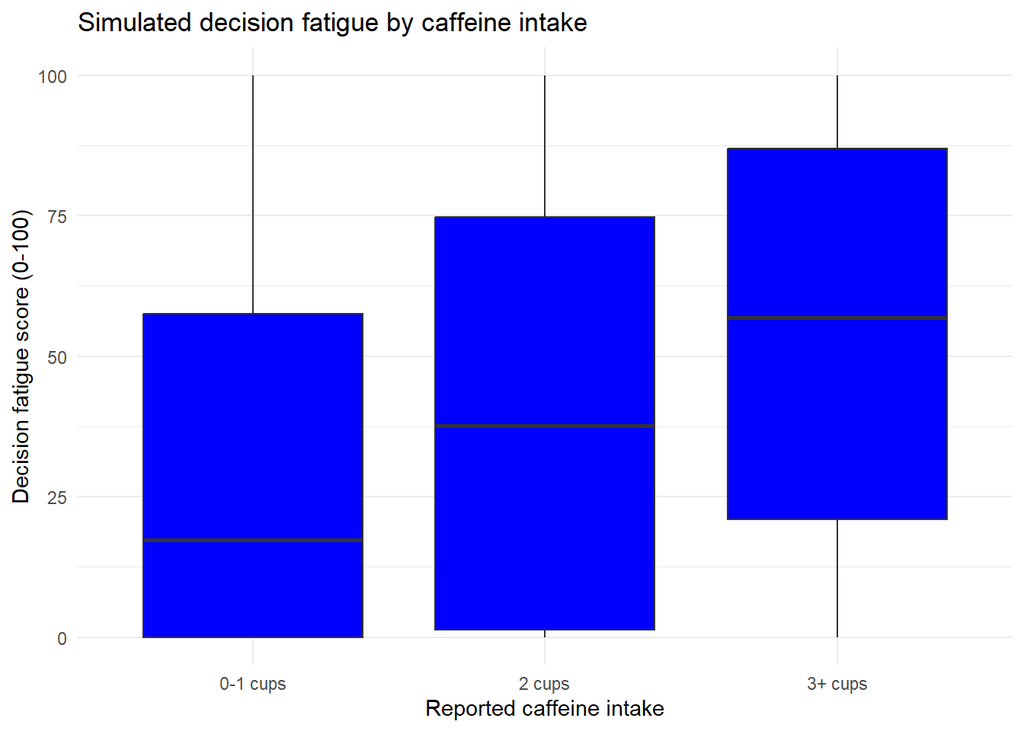

```r
ggplot(
  decisions,
  aes(x = caffeine_bins, y = Decision_Fatigue_Score)
) +
  geom_boxplot(fill = "Blue", outlier.alpha = 0.15) +
  labs(
    title = "Simulated decision fatigue by caffeine intake",
    x = "Reported caffeine intake",
    y = "Decision fatigue score (0-100)"
  ) +
  theme_minimal()
```

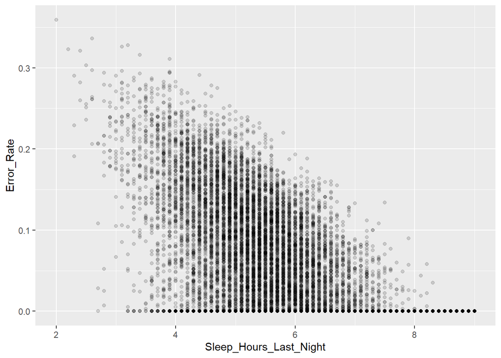

```r
ggplot(decisions) +
  geom_point(aes(Sleep_Hours_Last_Night, Error_Rate), alpha = 0.15)
```

```r
cor.test(decisions$Error_Rate, decisions$Decision_Fatigue_Score)
```

```
##
##  Pearson's product-moment correlation
##
## data:  decisions$Error_Rate and decisions$Decision_Fatigue_Score
## t = 202.28, df = 24998, p-value < 2.2e-16
## alternative hypothesis: true correlation is not equal to 0
## 95 percent confidence interval:
##  0.7831332 0.7925363
## sample estimates:
##       cor
## 0.7878807
```

```r
cor.test(decisions$Sleep_Hours_Last_Night, decisions$Decision_Fatigue_Score)
```

```
##
##  Pearson's product-moment correlation
##
## data:  decisions$Sleep_Hours_Last_Night and decisions$Decision_Fatigue_Score
## t = -96.826, df = 24998, p-value < 2.2e-16
## alternative hypothesis: true correlation is not equal to 0
## 95 percent confidence interval:
##  -0.5312103 -0.5131795
## sample estimates:
##        cor
## -0.5222533
```

[figure not shown]

```r
correlation_data <- decisions |>
  transmute(
    Caffeine = Caffeine_Intake_Cups,
    Sleep = Sleep_Hours_Last_Night,
    Fatigue = Decision_Fatigue_Score
  )

corrgram(correlation_data)
```

I wonder what would happen if we find the correlation between sleep hours and decision fatigue taking out caffeine intake

```r
pcor.test(x = decisions$Decision_Fatigue_Score, y = decisions$Sleep_Hours_Last_Night, z = decisions$Caffeine_Intake_Cups)
```

```
##     estimate p.value statistic     n gp  Method
## 1 -0.5065463       0 -92.88565 25000  1 pearson
```

After controlling for caffeine intake, sleep duration and decision fatigue remain negatively correlated within the synthetic dataset (partial r ≈ −0.507).

## Comparing Lower and Higher Caffeine Intake

Compare mean fatigue scores between the 0-1 cup and 3+ cup groups using Welch’s two-sample t-test.

```r
low_caffeine <- decisions |>
  filter(caffeine_bins == "0-1 cups") |>
  pull(Decision_Fatigue_Score)

high_caffeine <- decisions |>
  filter(caffeine_bins == "3+ cups") |>
  pull(Decision_Fatigue_Score)

# Calculate the difference as higher intake minus lower intake.
mean(high_caffeine) - mean(low_caffeine)
```

```
## [1] 22.31156
```

```r
t.test(
  x = high_caffeine,
  y = low_caffeine,
  var.equal = FALSE
)
```

```
##
##  Welch Two Sample t-test
##
## data:  high_caffeine and low_caffeine
## t = 42.266, df = 15785, p-value < 2.2e-16
## alternative hypothesis: true difference in means is not equal to 0
## 95 percent confidence interval:
##  21.27683 23.34628
## sample estimates:
## mean of x mean of y
##  53.45128  31.13973
```

The 3+ cup group has an approximately 22.31-point higher mean fatigue score than the 0-1 cup group. This comparison describes an unadjusted association within the synthetic dataset. It does not establish that caffeine causes higher fatigue.

## Regression Analysis

```r
model <- lm(Decision_Fatigue_Score ~ Caffeine_Intake_Cups + Sleep_Hours_Last_Night, data = decisions)

summary(model)
```

```
##
## Call:
## lm(formula = Decision_Fatigue_Score ~ Caffeine_Intake_Cups +
##     Sleep_Hours_Last_Night, data = decisions)
##
## Residuals:
##    Min     1Q Median     3Q    Max
## -91.71 -23.78  -2.95  22.89 102.03
##
## Coefficients:
##                        Estimate Std. Error t value Pr(>|t|)
## (Intercept)            129.2194     1.1451  112.84   <2e-16 ***
## Caffeine_Intake_Cups     5.2565     0.1359   38.67   <2e-16 ***
## Sleep_Hours_Last_Night -16.2034     0.1744  -92.89   <2e-16 ***
## ---
## Signif. codes:  0 '***' 0.001 '**' 0.01 '*' 0.05 '.' 0.1 ' ' 1
##
## Residual standard error: 30.41 on 24997 degrees of freedom
## Multiple R-squared:  0.3138, Adjusted R-squared:  0.3137
## F-statistic:  5716 on 2 and 24997 DF,  p-value: < 2.2e-16
```

```r
confint(model)
```

```
##                             2.5 %     97.5 %
## (Intercept)            126.974890 131.463979
## Caffeine_Intake_Cups     4.990094   5.522922
## Sleep_Hours_Last_Night -16.545294 -15.861451
```

Decision_Fatigue_Hat = 129.219 + 5.257 * (Caffeine_Intake_Cups) - 16.203 * (Sleep_Hours_Last_Night)

```r
lm.beta(model)
```

```
##
## Call:
## lm(formula = Decision_Fatigue_Score ~ Caffeine_Intake_Cups +
##     Sleep_Hours_Last_Night, data = decisions)
##
## Standardized Coefficients::
##            (Intercept)   Caffeine_Intake_Cups Sleep_Hours_Last_Night
##                     NA              0.2048633             -0.4920427
```

In this two-predictor model, an additional cup of caffeine is associated with an approximately 5.26-point higher predicted fatigue score when sleep duration is held constant. An additional hour of sleep is associated with an approximately 16.20-point lower predicted fatigue score when caffeine intake is held constant.

Among the two included predictors, sleep duration has the larger absolute standardized coefficient. These estimates describe relationships within synthetic data and do not establish causal effects in real people.

## Model Diagnostics

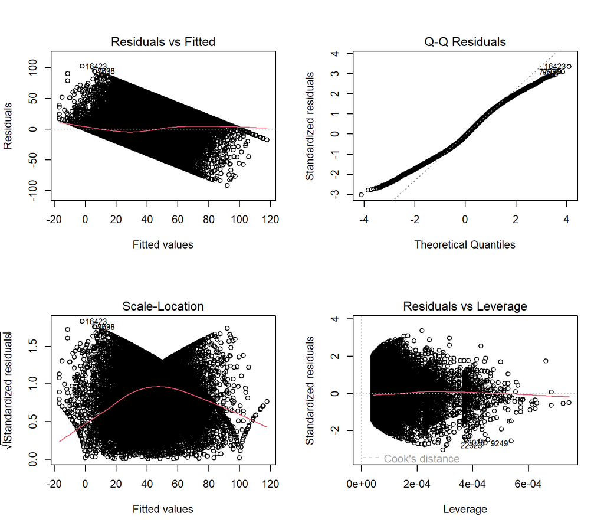

```r
old_par <- par(mfrow = c(2, 2))
plot(model)
```

```r
par(old_par)
```

The diagnostic plots show the limitations of the two-predictor linear model. Residual variation changes across fitted values, and the Q–Q plot shows departures from the line of normality. Some fitted scores also fall outside the outcome’s possible range of 0–100.

The model explains approximately 31.4% of the variation in fatigue scores within this dataset. Its residual standard error is approximately 30.4 points, indicating substantial unexplained variation. These findings support treating the model as an exploratory baseline. The usual regression confidence intervals and significance tests should be interpreted cautiously because the diagnostics suggest unequal residual variance.

Overall, higher caffeine intake is associated with higher fatigue scores in the unadjusted comparison and in the model controlling for sleep. Sleep duration has the larger absolute standardized coefficient among the two included predictors. These findings describe synthetic data and do not establish causal effects or validate predictions for real people.